# Informe del Curso de Programación

Grupo 3

20/9/2020

## Regresión lineal comparando la temperatura del mar y latitud

Cargamos las librerias que usaremos en este ejercicio.

```r
library(rgee)
library(mapview)
library(mapedit)
library(tidyverse)
library(sf)
library(raster)
```

Necesitamos iniciar nuestra cuenta

```r
ee_Initialize()
```

Creamos un area de interés mediante el uso de mapview y editmap, luego selecionamos todos sus atributos

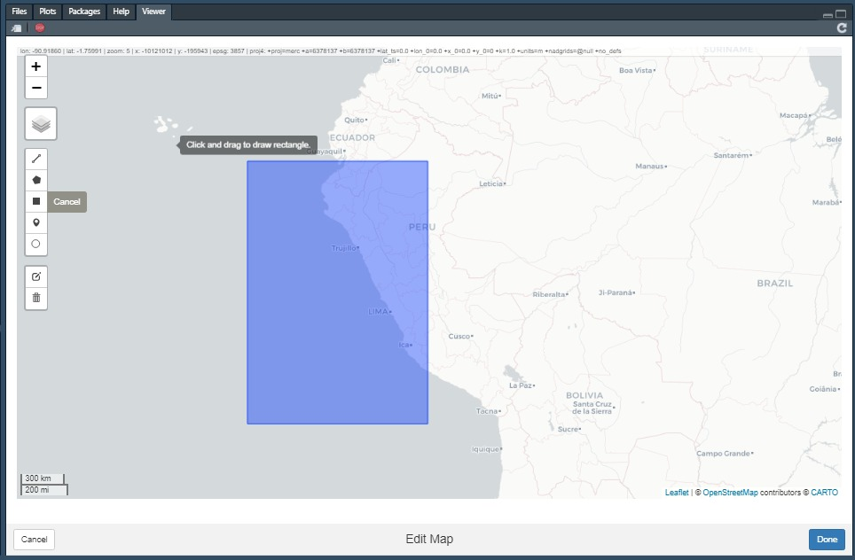

Área seleccionada

```r
area <- mapview() %>% editMap()
area_sf <- area$all
```

Convertimos el área a un objeto Earth Engine. Exportamos como un objeto Earth Engine

```r
area_ee <- sf_as_ee(area_sf)
```

Llamamos a la colección de imagen de la base de datos de Google Earth Engine para extraer la temperatura y salinidad a nivel de la superficie del mar. Filtramos la media de los datos

```r
imagen <- ee$ImageCollection("HYCOM/sea_temp_salinity")$
  filterDate(ee$Date("2018-01-01"), ee$Date("2018-01-31"))$
  mean()
```

Descargamos las imagenes a nuestro directorio local mediante ee_as_raster

```r
area_stack <- ee_as_raster(image = imagen,
                           region = area_ee$geometry())
```

Selecionamos las bandas que usaremos; en este caso la temperatura y salinidad superficial

```r
area_temp <- area_stack[["water_temp_0"]]
mar_salinidad <- area_stack[["salinity_0"]]
```

Aunque las unidades de la temperatura esten en grados centrigrados podemos obtener la escala apropiada con los valores que nos ofrece la tabla de las bandas del dataset en GEE

[figure not shown]

Tanto para la temperatura como la salinidad y lo guardamos con los mismos nombres

```r
mar_temperatura <- (mar_temperatura * 0.001) + 20
mar_salinidad <- (mar_salinidad * 0.001) + 20
```

Marcamos unos puntos aleatorios y nuevamente selecionamos todos sus atributos

[figure not shown]

Puntos seleccionados

```r
puntos <- mapview(area_sf) %>% editMap()
puntos_sf <- punto$all
```

Con estas lineas codigo extraemos los valores de latitud y longitud del “sf” y guardamos con el mismo nombre

```r
puntos_sf <- puntos_sf %>%
  mutate(lon = unlist(map(puntos_sf$geometry,1)),
         lat = unlist(map(puntos_sf$geometry,2)))
```

Extraemos los datos de temperaturas y salinidad con el archivo raster descargado de GEE a los puntos seleccionados anteriormente. Los nombres de las columnas lo definimos añadiendole despues del simbolo del dolar

```r
puntos_sf$temp <- raster::extract(mar_temperatura, puntos_sf)
puntos_sf$sal <- raster::extract(mar_salinidad, puntos_sf)
```

Revisamos los datos creados anteriormente

```r
puntos_sf
```

```
## Simple feature collection with 31 features and 5 fields
## geometry type:  POINT
## dimension:      XY
## bbox:           xmin: -84.58863 ymin: -17.76793 xmax: -79.75037 ymax: -5.177822
## geographic CRS: WGS 84
## First 10 features:
##    X_1       lon        lat     temp      sal                    geometry
## 1    1 -84.58863  -5.308381 20.94643 35.44510 POINT (-84.58863 -5.308381)
## 2    2 -82.87431  -5.439616 21.03063 35.41690 POINT (-82.87431 -5.439616)
## 3    3 -83.00946  -5.177822 21.03063 35.41690 POINT (-83.00946 -5.177822)
## 4    4 -84.35014  -6.838238 21.76173 35.57230 POINT (-84.35014 -6.838238)
## 5    5 -84.26223  -8.492905 22.50850 35.53470 POINT (-84.26223 -8.492905)
## 6    6 -84.10838  -9.989050 22.76580 35.57717  POINT (-84.10838 -9.98905)
## 7    7 -84.06442 -11.435283 23.49243 35.53320 POINT (-84.06442 -11.43528)
## 8    8 -84.06442 -12.445473 23.94320 35.47250 POINT (-84.06442 -12.44547)
## 9    9 -84.32828 -13.537905 24.48660 35.20333 POINT (-84.32828 -13.53791)
## 10  10 -83.99860 -14.943266 24.55450 35.19697  POINT (-83.9986 -14.94327)
```

Convertimos a un tibble y seleccionamos las colummnas que usaremos

```r
puntos_data <- puntos_sf %>%
  as_tibble() %>%
  dplyr::select(lat, lon, temp, sal)
head(puntos_data)
```

```
## # A tibble: 6 x 4
##     lat   lon  temp   sal
##   <dbl> <dbl> <dbl> <dbl>
## 1 -5.31 -84.6  20.9  35.4
## 2 -5.44 -82.9  21.0  35.4
## 3 -5.18 -83.0  21.0  35.4
## 4 -6.84 -84.4  21.8  35.6
## 5 -8.49 -84.3  22.5  35.5
## 6 -9.99 -84.1  22.8  35.6
```

Podemos comparar graficamente la relacion entre las variables

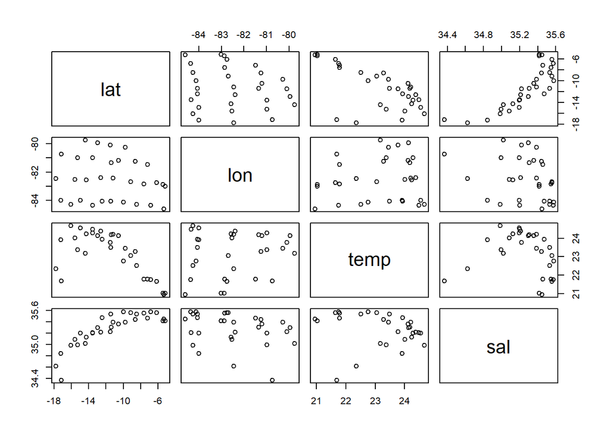

```r
pairs(puntos_data)
```

```r
cor(puntos_data)
```

```
##             lat        lon       temp        sal
## lat   1.0000000 -0.1669640 -0.6374909  0.8209327
## lon  -0.1669640  1.0000000  0.1324440 -0.2789708
## temp -0.6374909  0.1324440  1.0000000 -0.1872676
## sal   0.8209327 -0.2789708 -0.1872676  1.0000000
```

Realizamos una regresion lineal comparando la latitud con la salinidad

```r
regresion_salinidad <- lm(lat ~ sal, data = puntos_data)
summary(regresion_salinidad)
```

```
##
## Call:
## lm(formula = lat ~ sal, data = puntos_data)
##
## Residuals:
##     Min      1Q  Median      3Q     Max
## -3.2146 -1.3979 -0.3785  0.8665  4.6461
##
## Coefficients:
##             Estimate Std. Error t value Pr(>|t|)
## (Intercept) -387.585     48.591  -7.976 8.51e-09 ***
## sal           10.666      1.378   7.742 1.55e-08 ***
## ---
## Signif. codes:  0 '***' 0.001 '**' 0.01 '*' 0.05 '.' 0.1 ' ' 1
##
## Residual standard error: 2.18 on 29 degrees of freedom
## Multiple R-squared:  0.6739, Adjusted R-squared:  0.6627
## F-statistic: 59.94 on 1 and 29 DF,  p-value: 1.546e-08
```

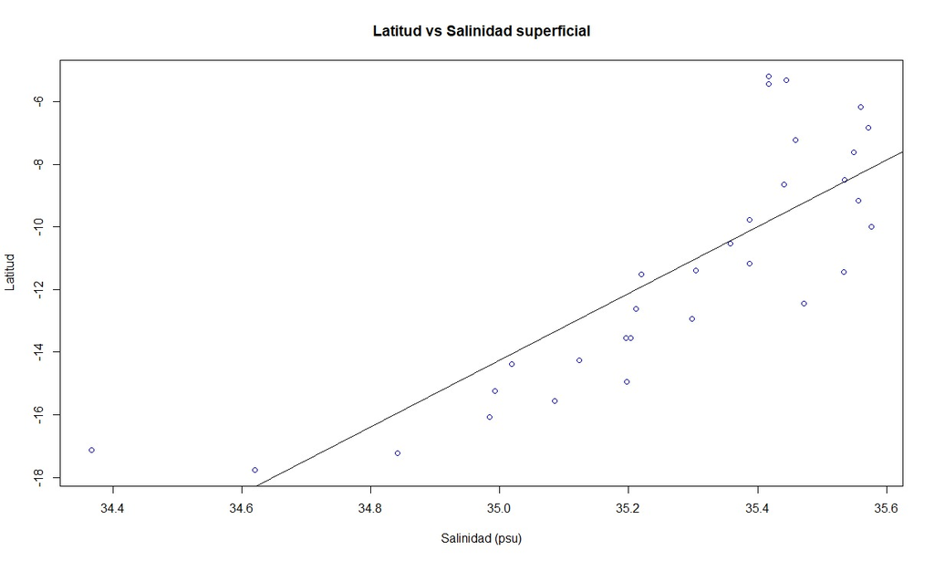

```r
plot(puntos_data$sal, puntos_data$lat,
     main = "Latitud vs Salinidad superficial",
     ylab = "Latitud",
     xlab = "Salinidad (psu)",
     col = "blue")
abline(regresion_salinidad)
```

Ahora para la latitud con la temperatura

```r
regresion_temperatura <- lm(lat ~ temp, data = puntos_data)
summary(regresion_temperatura)
```

```
##
## Call:
## lm(formula = lat ~ temp, data = puntos_data)
##
## Residuals:
##     Min      1Q  Median      3Q     Max
## -8.7135 -0.7008  0.9947  1.8172  3.0276
##
## Coefficients:
##             Estimate Std. Error t value Pr(>|t|)
## (Intercept)  35.4664    10.5321   3.367 0.002155 **
## temp         -2.0233     0.4541  -4.456 0.000115 ***
## ---
## Signif. codes:  0 '***' 0.001 '**' 0.01 '*' 0.05 '.' 0.1 ' ' 1
##
## Residual standard error: 2.942 on 29 degrees of freedom
## Multiple R-squared:  0.4064, Adjusted R-squared:  0.3859
## F-statistic: 19.85 on 1 and 29 DF,  p-value: 0.0001147
```

Ploteamos la temperatura y añadimos la linea de regresion

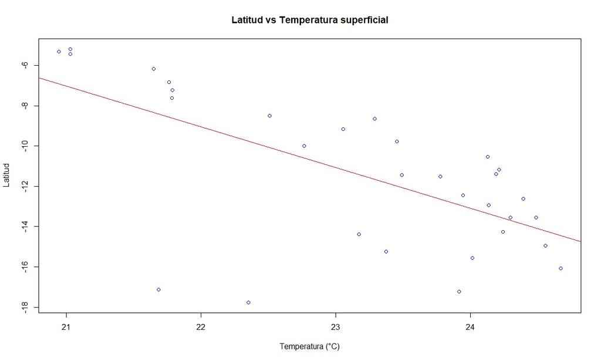

```r
plot(puntos_data$temp, puntos_data$lat,
     main = "Latitud vs Temperatura superficial",
     ylab = "Latitud",
     xlab = "Temperatura (°C)",
     col = "blue")
abline(regresion_temperatura, col = "red")
```